# HW 2: Supervised Learning Models

```python
# import modules
import numpy as np
import pandas as pd

# print plots if needed
%matplotlib inline

# set number of rows pandas display for data frame
pd.options.display.max_rows = 10
```

## Part 1: Regression on California Test Scores

```python
data = pd.read_csv("https://vincentarelbundock.github.io/Rdatasets/csv/Ecdat/Caschool.csv Links to an external site.",
                  index_col=0)
data.head()
```

|  | distcod | county | district | grspan | enrltot | teachers | calwpct | mealpct | computer | testscr | compstu | expnstu | str | avginc | elpct | readscr | mathscr |
| --- | --- | --- | --- | --- | --- | --- | --- | --- | --- | --- | --- | --- | --- | --- | --- | --- | --- |
| 1 | 75119 | Alameda | Sunol Glen Unified | KK-08 | 195 | 10.900000 | 0.510200 | 2.040800 | 67 | 690.799988 | 0.343590 | 6384.911133 | 17.889910 | 22.690001 | 0.000000 | 691.599976 | 690.000000 |
| 2 | 61499 | Butte | Manzanita Elementary | KK-08 | 240 | 11.150000 | 15.416700 | 47.916698 | 101 | 661.200012 | 0.420833 | 5099.380859 | 21.524664 | 9.824000 | 4.583333 | 660.500000 | 661.900024 |
| 3 | 61549 | Butte | Thermalito Union Elementary | KK-08 | 1550 | 82.900002 | 55.032299 | 76.322601 | 169 | 643.599976 | 0.109032 | 5501.954590 | 18.697226 | 8.978000 | 30.000002 | 636.299988 | 650.900024 |
| 4 | 61457 | Butte | Golden Feather Union Elementary | KK-08 | 243 | 14.000000 | 36.475399 | 77.049202 | 85 | 647.700012 | 0.349794 | 7101.831055 | 17.357143 | 8.978000 | 0.000000 | 651.900024 | 643.500000 |
| 5 | 61523 | Butte | Palermo Union Elementary | KK-08 | 1335 | 71.500000 | 33.108601 | 78.427002 | 171 | 640.849976 | 0.128090 | 5235.987793 | 18.671329 | 9.080333 | 13.857677 | 641.799988 | 639.900024 |

```python
y = data['testscr']

X = data.loc[:, data.columns.difference(['testscr', 'readscr', 'mathscr','distcod', 'county', 'district', 'grspan'])]
```

## 1.1 Visualize the univariate distribution of the target feature and each of the three continuous explanatory variables that you think are likely to have a relationship with the target feature.

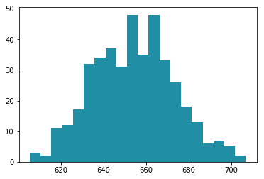

```python
y.hist(grid = False, bins = 20, color='#208EA5')
```

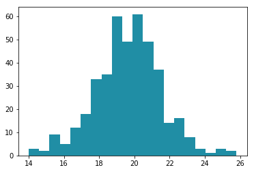

```python
X['str'].hist(grid = False, bins = 20, color='#208EA5')
```

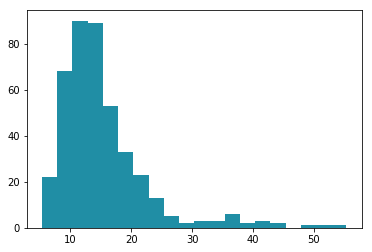

```python
X['avginc'].hist(grid = False, bins = 20, color='#208EA5')
```

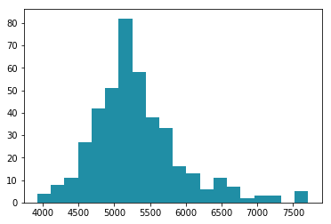

```python
X['expnstu'].hist(grid = False, bins = 20, color='#208EA5')
```

## 1.2 Visualize the dependency of the target on each feature from 1.1.

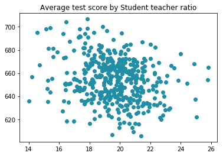

```python
import matplotlib.pyplot as plt
plt.scatter(data['str'], data['testscr'],  marker='o',color='#208EA5')

# add a title
plt.title("Average test score by Student teacher ratio")

# to display the chart
plt.show()
```

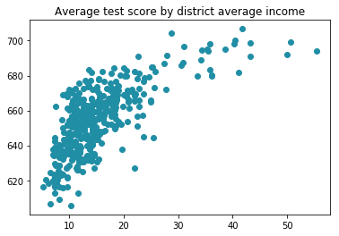

```python
import matplotlib.pyplot as plt
plt.scatter(data['avginc'], data['testscr'],  marker='o',color='#208EA5')

# add a title
plt.title("Average test score by district average income")

# to display the chart
plt.show()
```

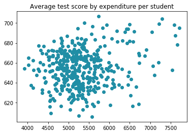

```python
import matplotlib.pyplot as plt
plt.scatter(data['expnstu'], data['testscr'],  marker='o',color='#208EA5')

# add a title
plt.title("Average test score by expenditure per student")

# to display the chart
plt.show()
```

## 1.3 Split data in training and test set. Build models that evaluate the relationship between all available X variables in the California test dataset and the target variable. Evaluate KNN for regression, Linear Regression (OLS), Ridge, and Lasso using cross-validation with the default parameters. Does scaling the data with the StandardScaler help?

### 1.3.1 Train test split

```python
from sklearn.model_selection import train_test_split
# shuffling the dataset
X_train, X_test, y_train, y_test = train_test_split(X, y, random_state=1)
```

```python
X_train.head()
```

|  | avginc | calwpct | compstu | computer | elpct | enrltot | expnstu | mealpct | str | teachers |
| --- | --- | --- | --- | --- | --- | --- | --- | --- | --- | --- |
| 316 | 11.826000 | 13.375800 | 0.237500 | 38 | 2.500000 | 160 | 6870.346191 | 53.503201 | 14.705882 | 10.880000 |
| 14 | 8.279000 | 24.609400 | 0.000000 | 0 | 20.533880 | 487 | 4818.612793 | 77.148399 | 20.008217 | 24.340000 |
| 355 | 12.640000 | 2.451000 | 0.121212 | 24 | 0.000000 | 198 | 4593.196777 | 12.745100 | 22.000000 | 9.000000 |
| 62 | 10.905643 | 58.752201 | 0.108992 | 560 | 32.989491 | 5138 | 5606.781738 | 84.999001 | 17.670021 | 290.774994 |
| 172 | 12.749143 | 41.773399 | 0.152223 | 606 | 8.842000 | 3981 | 5358.517090 | 51.770901 | 18.957144 | 210.000000 |

### 1.3.2 Build Models

### KNN for regression

```python
from sklearn.neighbors import KNeighborsRegressor

knn = KNeighborsRegressor(n_neighbors=3)

knn.fit(X_train, y_train)

print("Training set score: {:.3f}".format(knn.score(X_train, y_train)))
print("Test set score: {:.3f}".format(knn.score(X_test, y_test)))
```

```
Training set score: 0.424
Test set score: 0.029
```

### Linear Regression (OLS)

```python
from sklearn.linear_model import LinearRegression

lr = LinearRegression()
lr.fit(X_train, y_train)
print("lr.coef_: {}".format(lr.coef_))
print("lr.intercept_: {}".format(lr.intercept_))

print("Training set score: {:.3f}".format(lr.score(X_train, y_train)))
print("Test set score: {:.3f}".format(lr.score(X_test, y_test)))
```

```
lr.coef_: [ 5.44223554e-01 -8.83598155e-02  5.80342195e+00  3.30043134e-03
 -2.14288402e-01  1.23265852e-03  2.00663899e-03 -3.81931221e-01
 -2.59144037e-01 -3.24527985e-02]
lr.intercept_: 661.1394147432457
Training set score: 0.832
Test set score: 0.746
```

### Ridge

```python
from sklearn.linear_model import Ridge
ridge = Ridge()
ridge.fit(X_train, y_train)
print("Training set score: {:.3f}".format(ridge.score(X_train, y_train)))
print("Test set score: {:.3f}".format(ridge.score(X_test, y_test)))
```

```
Training set score: 0.832
Test set score: 0.745
```

Increasing alpha forces coefficients to move more toward zero

```python
ridge10 = Ridge(alpha=10).fit(X_train, y_train)
print("Training set score: {:.3f}".format(ridge10.score(X_train, y_train)))
print("Test set score: {:.3f}".format(ridge10.score(X_test, y_test)))
```

```
Training set score: 0.832
Test set score: 0.745
```

Decreasing alpha means approach to OLS

```python
ridge01 = Ridge(alpha=0.1).fit(X_train, y_train)
print("Training set score: {:.3f}".format(ridge01.score(X_train, y_train)))
print("Test set score: {:.3f}".format(ridge01.score(X_test, y_test)))
```

```
Training set score: 0.832
Test set score: 0.746
```

### Lasso

```python
from sklearn.linear_model import Lasso
lasso = Lasso(max_iter=10000)
lasso.fit(X_train, y_train)
print("Training set score: {:.3f}".format(lasso.score(X_train, y_train)))
print("Test set score: {:.3f}".format(lasso.score(X_test, y_test)))
print("Number of features used: {}".format(np.sum(lasso.coef_ != 0)))
```

```
Training set score: 0.831
Test set score: 0.744
Number of features used: 8
```

Increasing alpha forces more coefficients to zero

```python
lasso5 = Lasso(alpha=5, max_iter=100000).fit(X_train, y_train)
print("Training set score: {:.3f}".format(lasso5.score(X_train, y_train)))
print("Test set score: {:.3f}".format(lasso5.score(X_test, y_test)))
print("Number of features used: {}".format(np.sum(lasso5.coef_ != 0)))
```

```
Training set score: 0.828
Test set score: 0.737
Number of features used: 7
```

Decreasing alpha means approach to OLS

```python
lasso001 = Lasso(alpha=0.01, max_iter=100000).fit(X_train, y_train)
print("Training set score: {:.3f}".format(lasso001.score(X_train, y_train)))
print("Test set score: {:.3f}".format(lasso001.score(X_test, y_test)))
print("Number of features used: {}".format(np.sum(lasso001.coef_ != 0)))
```

```
Training set score: 0.832
Test set score: 0.745
Number of features used: 10
```

### 1.3.3 Evaluate Models Using Cross-Validation

### KNN for Regression

```python
from sklearn.model_selection import cross_val_score

print("Average cross-validation score: {:.3f}".format(np.mean(cross_val_score(KNeighborsRegressor(),
                                                                              X_train, y_train, cv=10))))
```

```
Average cross-validation score: -0.088
```

### Linear Regression (OLS)

```python
print("Average cross-validation score: {:.3f}".format(np.mean(cross_val_score(LinearRegression(),
                                                                              X_train, y_train, cv=10))))
```

```
Average cross-validation score: 0.807
```

### Ridge

```python
print("Average cross-validation score: {:.3f}".format(np.mean(cross_val_score(Ridge(),
                                                                              X_train, y_train, cv=10))))
```

```
Average cross-validation score: 0.808
```

### Lasso

```python
print("Average cross-validation score: {:.3f}".format(np.mean(cross_val_score(Lasso(max_iter=100000),
                                                                              X_train, y_train, cv=10))))
```

```
Average cross-validation score: 0.810
```

### 1.3.4 Does scaling the data with the StandardScaler help?

### Scaling

```python
from sklearn import preprocessing
# Use transformed data with a model:
scaler = preprocessing.StandardScaler()
scaler.fit(X_train)
X_train_scaled = scaler.transform(X_train)
X_test_scaled = scaler.transform(X_test)
```

### KNN for Regression

Scaling help improve KNN for regression a lot, since KNN model is larged determined by the scale of variables.

```python
knn.fit(X_train, y_train)
print("Training without scale: {:.3f}".format(knn.score(X_train, y_train)))
print("Test without scale: {:.3f}".format(knn.score(X_test, y_test)))

knn.fit(X_train_scaled, y_train)
print("Training with scale: {:.3f}".format(knn.score(X_train_scaled, y_train)))
print("Test with scale: {:.3f}".format(knn.score(X_test_scaled, y_test)))
```

```
Training without scale: 0.424
Test without scale: 0.029
Training with scale: 0.878
Test with scale: 0.692
```

```python
print("Average cross-validation score without scale: {:.3f}".format(np.mean(cross_val_score(KNeighborsRegressor(),
                                                                              X_train,
                                                                              y_train, cv=10))))

print("Average cross-validation score with scale: {:.3f}".format(np.mean(cross_val_score(KNeighborsRegressor(),
                                                                              X_train_scaled,
                                                                              y_train, cv=10))))
```

```
Average cross-validation score without scale: -0.088
Average cross-validation score with scale: 0.731
```

### Linear Regression (OLS)

Scaling does not affect OLS model

```python
lr.fit(X_train, y_train)
print("Training without scale: {:.3f}".format(lr.score(X_train, y_train)))
print("Test without scale: {:.3f}".format(lr.score(X_test, y_test)))

lr.fit(X_train_scaled, y_train)
print("Training with scale: {:.3f}".format(lr.score(X_train_scaled, y_train)))
print("Test with scale: {:.3f}".format(lr.score(X_test_scaled, y_test)))
```

```
Training without scale: 0.832
Test without scale: 0.746
Training with scale: 0.832
Test with scale: 0.746
```

```python
print("Average cross-validation score without scale: {:.3f}".format(np.mean(cross_val_score(LinearRegression(),
                                                                              X_train,
                                                                              y_train, cv=10))))

print("Average cross-validation score with scale: {:.3f}".format(np.mean(cross_val_score(LinearRegression(),
                                                                              X_train_scaled,
                                                                              y_train, cv=10))))
```

```
Average cross-validation score without scale: 0.807
Average cross-validation score with scale: 0.807
```

### Ridge

```python
ridge.fit(X_train, y_train)
print("Training without scale: {:.3f}".format(ridge.score(X_train, y_train)))
print("Test without scale: {:.3f}".format(ridge.score(X_test, y_test)))

ridge.fit(X_train_scaled, y_train)
print("Training with scale: {:.3f}".format(ridge.score(X_train_scaled, y_train)))
print("Test with scale: {:.3f}".format(ridge.score(X_test_scaled, y_test)))
```

```
Training without scale: 0.832
Test without scale: 0.745
Training with scale: 0.832
Test with scale: 0.748
```

```python
print("Average cross-validation score without scale: {:.3f}".format(np.mean(cross_val_score(Ridge(),
                                                                              X_train,
                                                                              y_train, cv=10))))

print("Average cross-validation score with scale: {:.3f}".format(np.mean(cross_val_score(Ridge(),
                                                                              X_train_scaled,
                                                                              y_train, cv=10))))
```

```
Average cross-validation score without scale: 0.808
Average cross-validation score with scale: 0.807
```

### Lasso

```python
lasso.fit(X_train, y_train)
print("Training without scale: {:.3f}".format(lasso.score(X_train, y_train)))
print("Test without scale: {:.3f}".format(lasso.score(X_test, y_test)))

lasso.fit(X_train_scaled, y_train)
print("Training with scale: {:.3f}".format(lasso.score(X_train_scaled, y_train)))
print("Test with scale: {:.3f}".format(lasso.score(X_test_scaled, y_test)))
```

```
Training without scale: 0.831
Test without scale: 0.744
Training with scale: 0.823
Test with scale: 0.742
```

```python
print("Average cross-validation score without scale: {:.3f}".format(np.mean(cross_val_score(Lasso(max_iter=100000),
                                                                              X_train,
                                                                              y_train, cv=10))))

print("Average cross-validation score with scale: {:.3f}".format(np.mean(cross_val_score(Lasso(max_iter=100000),
                                                                              X_train_scaled,
                                                                              y_train, cv=10))))
```

```
Average cross-validation score without scale: 0.810
Average cross-validation score with scale: 0.805
```

## 1.4 Tune the parameters of the models where possible using GridSearchCV. Do the results improve?

**Using GridsearchCV to tune the parameter improves our models' perfermance on predicting**

### KNN for regression

```python
from sklearn.model_selection import GridSearchCV

param_grid = {'n_neighbors': np.arange(1, 15, 1)}

grid = GridSearchCV(KNeighborsRegressor(), param_grid=param_grid, cv=10)

grid.fit(X_train_scaled, y_train)

print("best mean cross-validation score: {:.3f}".format(grid.best_score_))
print("best parameters: {}".format(grid.best_params_))
print("test-set score: {:.3f}".format(grid.score(X_test_scaled, y_test)))
```

```
best mean cross-validation score: 0.765
best parameters: {'n_neighbors': 13}
test-set score: 0.706
```

### Ridge

```python
from sklearn.model_selection import GridSearchCV

param_grid = {'alpha': np.arange(0, 30, 1)} #np.arange creates sequence of numbers for each k value

grid = GridSearchCV(Ridge(), param_grid=param_grid, cv=10)

grid.fit(X_train_scaled, y_train)

#extract best score and parameter by calling objects "best_score_" and "best_params_"
print("best mean cross-validation score: {:.3f}".format(grid.best_score_))
print("best parameters: {}".format(grid.best_params_))
print("test-set score: {:.3f}".format(grid.score(X_test_scaled, y_test)))
```

```
best mean cross-validation score: 0.808
best parameters: {'alpha': 10}
test-set score: 0.749
```

### Lasso

```python
param_grid = {'alpha': np.arange(0.01, 20, 0.1)} #np.arange creates sequence of numbers for each k value

grid = GridSearchCV(Lasso(max_iter=100000), param_grid=param_grid, cv=10)

grid.fit(X_train_scaled, y_train)

#extract best score and parameter by calling objects "best_score_" and "best_params_"
print("best mean cross-validation score: {:.3f}".format(grid.best_score_))
print("best parameters: {}".format(grid.best_params_))
print("test-set score: {:.3f}".format(grid.score(X_test_scaled, y_test)))
```

```
best mean cross-validation score: 0.809
best parameters: {'alpha': 0.21000000000000002}
test-set score: 0.749
```

## 1.5 Compare the coefficients of your two best linear models (not knn), do they agree on which features are important?

**I choose `Ridge(alpha=10)` and Lasso with `Lasso(alpha=0.21000000000000002)` to compare based on the `GridSearchCV` results.** **Two models agreed on the most important features is `mealpct` (percent qualifying for reduced-price lunch), `elpct` (percent of English learners) and `avginc` (district average income).**

```python
ridge10 = Ridge(alpha=10).fit(X_train_scaled, y_train)
print("ridge10.coef_: {}".format(ridge10.coef_))
print("ridge10.intercept_: {}".format(ridge10.intercept_))
```

```
ridge10.coef_: [ 3.93263723 -1.47292229  0.47246612  0.9048331  -4.29797339 -0.14706884
  1.18568776 -9.27650008 -0.33469443 -0.65639799]
ridge10.intercept_: 653.5317460317458
```

```python
lasso02 = Lasso(alpha=0.21000000000000002).fit(X_train_scaled, y_train)
print("lasso02.coef_: {}".format(lasso02.coef_))
print("lasso02.intercept_: {}".format(lasso02.intercept_))
```

```
lasso02.coef_: [  3.70158456  -0.7126675    0.52301986   0.          -3.78905691
  -0.           1.06009605 -10.46987237  -0.20298529  -0.        ]
lasso02.intercept_: 653.5317460317458
```

## 1.6 Discuss which final model you would choose to predict new data

**I would choose `Ridge(alpha=10)` as my final model. Firstly, it has the best test-set score; Secondly, though `Lasso(alpha=0.21000000000000002)` has the same test-set score, using L2 regularization would not exclude some features in the new data.**

## Part 2: Classification on red and white wine characteristics

```python
white = pd.read_csv("winequality-white.csv", sep = ';')
```

```python
red = pd.read_csv("winequality-red.csv", sep = ';')
```

Add a new column to each data frame called "winetype". For the white wine dataset label the values in this column with a 0, indicating white wine. For the red wine dataset, label values with a 1, indicating red wine. Combine both datasets into a single dataframe.

```python
white['winetype'] = 0
```

```python
red['winetype'] = 1
```

```python
wine = pd.concat([white,red], axis=0)
```

```python
wine.head()
```

|  | fixed acidity | volatile acidity | citric acid | residual sugar | chlorides | free sulfur dioxide | total sulfur dioxide | density | pH | sulphates | alcohol | quality | winetype |
| --- | --- | --- | --- | --- | --- | --- | --- | --- | --- | --- | --- | --- | --- |
| 0 | 7.0 | 0.27 | 0.36 | 20.7 | 0.045 | 45.0 | 170.0 | 1.0010 | 3.00 | 0.45 | 8.8 | 6 | 0 |
| 1 | 6.3 | 0.30 | 0.34 | 1.6 | 0.049 | 14.0 | 132.0 | 0.9940 | 3.30 | 0.49 | 9.5 | 6 | 0 |
| 2 | 8.1 | 0.28 | 0.40 | 6.9 | 0.050 | 30.0 | 97.0 | 0.9951 | 3.26 | 0.44 | 10.1 | 6 | 0 |
| 3 | 7.2 | 0.23 | 0.32 | 8.5 | 0.058 | 47.0 | 186.0 | 0.9956 | 3.19 | 0.40 | 9.9 | 6 | 0 |
| 4 | 7.2 | 0.23 | 0.32 | 8.5 | 0.058 | 47.0 | 186.0 | 0.9956 | 3.19 | 0.40 | 9.9 | 6 | 0 |

```python
wine.tail()
```

|  | fixed acidity | volatile acidity | citric acid | residual sugar | chlorides | free sulfur dioxide | total sulfur dioxide | density | pH | sulphates | alcohol | quality | winetype |
| --- | --- | --- | --- | --- | --- | --- | --- | --- | --- | --- | --- | --- | --- |
| 1594 | 6.2 | 0.600 | 0.08 | 2.0 | 0.090 | 32.0 | 44.0 | 0.99490 | 3.45 | 0.58 | 10.5 | 5 | 1 |
| 1595 | 5.9 | 0.550 | 0.10 | 2.2 | 0.062 | 39.0 | 51.0 | 0.99512 | 3.52 | 0.76 | 11.2 | 6 | 1 |
| 1596 | 6.3 | 0.510 | 0.13 | 2.3 | 0.076 | 29.0 | 40.0 | 0.99574 | 3.42 | 0.75 | 11.0 | 6 | 1 |
| 1597 | 5.9 | 0.645 | 0.12 | 2.0 | 0.075 | 32.0 | 44.0 | 0.99547 | 3.57 | 0.71 | 10.2 | 5 | 1 |
| 1598 | 6.0 | 0.310 | 0.47 | 3.6 | 0.067 | 18.0 | 42.0 | 0.99549 | 3.39 | 0.66 | 11.0 | 6 | 1 |

## 2.1 Visualize the univariate distribution of the target feature and each of the three explanatory variables that you think are likely to have a relationship with the target feature.

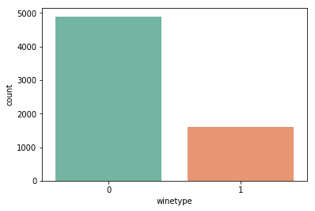

```python
import seaborn as sns
sns.countplot(x="winetype", data=wine, palette="Set2")
```

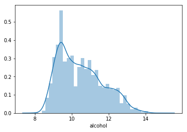

```python
sns.distplot(wine['alcohol'])
```

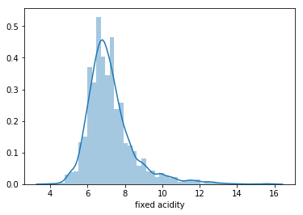

```python
sns.distplot(wine['fixed acidity'])
```

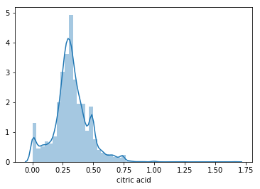

```python
sns.distplot(wine['citric acid'])
```

## 2.2 Visualize the dependency of the target on each feature from 2.1.

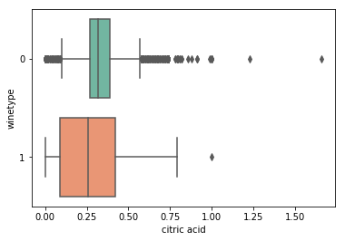

```python
sns.boxplot(y="winetype", x="citric acid", data=wine, orient="h", palette="Set2")
```

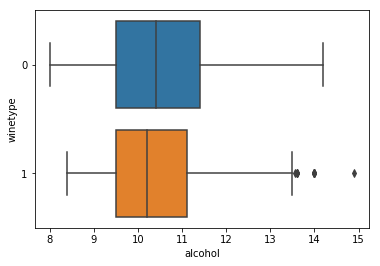

```python
sns.boxplot(y="winetype", x="alcohol", data=wine, orient="h")
```

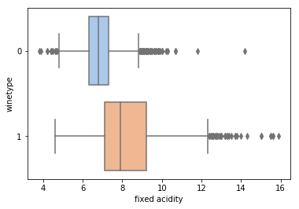

```python
sns.boxplot(y="winetype", x="fixed acidity", data=wine, orient="h", palette = "pastel")
```

## 2.2 Split data into training and test set. Build models that evaluate the relationship between all available X variables in the dataset and the target variable. Evaluate Logistic Regression, Penalized Logistic Regression, and KNN for classification using cross-validation. How different are the results? How does scaling the data with StandardScaler influence the results?

### Split Training and Test

```python
y = wine['winetype']

X = wine.loc[:, wine.columns != 'winetype']

# shuffling the dataset
X_train, X_test, y_train, y_test = train_test_split(X, y, random_state=5)
```

```python
X_train.head()
```

|  | fixed acidity | volatile acidity | citric acid | residual sugar | chlorides | free sulfur dioxide | total sulfur dioxide | density | pH | sulphates | alcohol | quality |
| --- | --- | --- | --- | --- | --- | --- | --- | --- | --- | --- | --- | --- |
| 1444 | 7.3 | 0.67 | 0.02 | 2.2 | 0.072 | 31.0 | 92.0 | 0.99566 | 3.32 | 0.68 | 11.1 | 6 |
| 66 | 7.5 | 0.52 | 0.11 | 1.5 | 0.079 | 11.0 | 39.0 | 0.99680 | 3.42 | 0.58 | 9.6 | 5 |
| 961 | 7.1 | 0.56 | 0.14 | 1.6 | 0.078 | 7.0 | 18.0 | 0.99592 | 3.27 | 0.62 | 9.3 | 5 |
| 2491 | 6.0 | 0.20 | 0.24 | 5.3 | 0.075 | 49.0 | 201.0 | 0.99466 | 3.21 | 0.43 | 9.5 | 5 |
| 2493 | 7.6 | 0.31 | 0.23 | 12.7 | 0.054 | 20.0 | 139.0 | 0.99836 | 3.16 | 0.50 | 9.7 | 4 |

### Scaling

```python
from sklearn import preprocessing
# Use transformed data with a model:
scaler = preprocessing.StandardScaler()
scaler.fit(X_train)
X_train_scaled = scaler.transform(X_train)
X_test_scaled = scaler.transform(X_test)
```

### Build Models and Evaluate

### KNN

**Build Model**

```python
from sklearn.neighbors import KNeighborsClassifier

knn = KNeighborsClassifier(n_neighbors=5)
knn.fit(X_train, y_train)

print("Training set score: {:.3f}".format(knn.score(X_train, y_train)))
print("Test set score: {:.3f}".format(knn.score(X_test, y_test)))
```

```
Training set score: 0.960
Test set score: 0.938
```

**Training with scaled data get improved result**

```python
knn.fit(X_train_scaled, y_train)

print("Training with scale set score: {:.3f}".format(knn.score(X_train_scaled, y_train)))
print("Test with scale set score: {:.3f}".format(knn.score(X_test_scaled, y_test)))
```

```
Training with scale set score: 0.994
Test with scale set score: 0.994
```

**Cross Validation**

```python
from sklearn.model_selection import cross_val_score

print("Average cross-validation score: {:.3f}".format(np.mean(cross_val_score(KNeighborsClassifier(),
                                                                              X_train, y_train, cv=10))))
```

```
Average cross-validation score: 0.943
```

With scaling, we get a higher predict score

```python
print("Average cross-validation score with scaling:: {:.3f}".format(np.mean(cross_val_score(KNeighborsClassifier(),
                                                                              X_train_scaled, y_train, cv=10))))
```

```
Average cross-validation score with scaling:: 0.993
```

### Logistic Regression

**Build Model**

```python
from sklearn.linear_model import LogisticRegression

logreg = LogisticRegression(C=1e90)

logreg.fit(X_train, y_train)

print("logreg .coef_: {}".format(logreg .coef_))

print("Training set score: {:.3f}".format(logreg.score(X_train, y_train)))
print("Test set score: {:.3f}".format(logreg.score(X_test, y_test)))
```

```
logreg .coef_: [[  1.37933076  12.791699    -0.38755615  -0.1514902   17.96551218
    0.05839286  -0.06355232 -17.26589021   7.39287084   9.34780803
   -0.53050872   0.04826096]]
Training set score: 0.989
Test set score: 0.991
```

**Training with scaled data get improved result**

```python
logreg.fit(X_train_scaled, y_train)

print("With scaling logreg .coef_: {}".format(logreg .coef_))

print("With scaling Training set score: {:.3f}".format(logreg.score(X_train_scaled, y_train)))
print("With scaling Test set score: {:.3f}".format(logreg.score(X_test_scaled, y_test)))
```

```
With scaling logreg .coef_: [[-0.16363364  1.23106878 -0.34129951 -4.60336162  0.76912171  1.14992851
  -2.83637555  4.99557407 -0.17447084  0.34125188  1.89156906  0.36139468]]
With scaling Training set score: 0.994
With scaling Test set score: 0.996
```

**Cross Validation**

```python
print("Average cross-validation score: {:.3f}".format(np.mean(cross_val_score(LogisticRegression(C=1e90),
                                                                              X_train, y_train, cv=10))))
```

```
Average cross-validation score: 0.987
```

With scaling, we get a higher predict score

```python
print("Average cross-validation score with scaling: {:.3f}".format(np.mean(cross_val_score(LogisticRegression(C=1e90),
                                                                              X_train_scaled, y_train, cv=10))))
```

```
Average cross-validation score with scaling: 0.993
```

### Penalized Logistic Regression

**Build Model**

```python
logreg = LogisticRegression(C=1)

logreg.fit(X_train, y_train)

print("logreg .coef_: {}".format(logreg .coef_))

print("Training set score: {:.3f}".format(logreg.score(X_train, y_train)))
print("Test set score: {:.3f}".format(logreg.score(X_test, y_test)))
```

```
logreg .coef_: [[ 0.69351965  7.86591635 -0.54155001 -0.16787247  2.50505967  0.04909166
  -0.06130386 -3.1711382   2.25828752  6.09757349 -0.73479254 -0.10142225]]
Training set score: 0.981
Test set score: 0.985
```

**Training with scaled data get improved result**

```python
logreg.fit(X_train_scaled, y_train)

print("With scaling logreg .coef_: {}".format(logreg .coef_))

print("With scaling Training set score: {:.3f}".format(logreg.score(X_train_scaled, y_train)))
print("With scaling Test set score: {:.3f}".format(logreg.score(X_test_scaled, y_test)))
```

```
With scaling logreg .coef_: [[ 0.35479618  1.22439923 -0.32048344 -3.06843166  0.8213788   0.8044157
  -2.56715057  3.42382927  0.24012907  0.48639375  1.15616032  0.30774051]]
With scaling Training set score: 0.993
With scaling Test set score: 0.996
```

**Cross Validation**

```python
print("Average cross-validation score: {:.3f}".format(np.mean(cross_val_score(LogisticRegression(C=1),
                                                                              X_train, y_train, cv=10))))
```

```
Average cross-validation score: 0.980
```

With scaling, we get a higher predict score

```python
print("Average cross-validation score with scaling: {:.3f}".format(np.mean(cross_val_score(LogisticRegression(C=1),
                                                                              X_train_scaled, y_train, cv=10))))
```

```
Average cross-validation score with scaling: 0.993
```

## 2.3 Tune the parameters where possible using GridSearchCV. Do the results improve?

### KNN

```python
from sklearn.model_selection import GridSearchCV

param_grid = {'n_neighbors': np.arange(1, 20, 1)}

grid = GridSearchCV(KNeighborsClassifier(), param_grid=param_grid, cv=10)

grid.fit(X_train_scaled, y_train)

print("best mean cross-validation score: {:.3f}".format(grid.best_score_))
print("best parameters: {}".format(grid.best_params_))
print("test-set score: {:.3f}".format(grid.score(X_test_scaled, y_test)))
```

```
best mean cross-validation score: 0.993
best parameters: {'n_neighbors': 16}
test-set score: 0.994
```

### Penalized Logistic Regression

```python
param_grid = {'C': np.arange(1, 1000, 10)}

grid = GridSearchCV(LogisticRegression(), param_grid=param_grid, cv=10)

grid.fit(X_train_scaled, y_train)

print("best mean cross-validation score: {:.3f}".format(grid.best_score_))
print("best parameters: {}".format(grid.best_params_))
print("test-set score: {:.3f}".format(grid.score(X_test_scaled, y_test)))
```

```
best mean cross-validation score: 0.993
best parameters: {'C': 11}
test-set score: 0.996
```

## 2.4 Change the cross-validation strategy in GridSearchCV from ‘stratified k-fold’ to ‘kfold’ with shuffling. Do the parameters for models that can be tuned change? Do they change if you change the random seed of the shuffling? Or if you change the random state of the split into training and test data?

```python
from sklearn.model_selection import KFold
```

**The parameters for models change**

```python
kfold = KFold(n_splits=5, shuffle = True, random_state = 2)

param_grid = {'n_neighbors': np.arange(1, 20, 1)}

grid = GridSearchCV(KNeighborsClassifier(), param_grid=param_grid, cv=kfold)

grid.fit(X_train_scaled, y_train)

print("best mean cross-validation score: {:.3f}".format(grid.best_score_))
print("best parameters: {}".format(grid.best_params_))
print("test-set score: {:.3f}".format(grid.score(X_test_scaled, y_test)))
```

```
best mean cross-validation score: 0.994
best parameters: {'n_neighbors': 1}
test-set score: 0.996
```

```python
kfold = KFold(n_splits=5, shuffle = True, random_state = 2)
param_grid = {'C': np.arange(1, 1000, 10)}

grid = GridSearchCV(LogisticRegression(), param_grid=param_grid, cv=kfold)

grid.fit(X_train_scaled, y_train)

print("best mean cross-validation score: {:.3f}".format(grid.best_score_))
print("best parameters: {}".format(grid.best_params_))
print("test-set score: {:.3f}".format(grid.score(X_test_scaled, y_test)))
```

```
best mean cross-validation score: 0.993
best parameters: {'C': 1}
test-set score: 0.996
```

```python
kfold = KFold(n_splits=5, shuffle = True, random_state = 99)

param_grid = {'n_neighbors': np.arange(1, 20, 1)}

grid = GridSearchCV(KNeighborsClassifier(), param_grid=param_grid, cv=kfold)

grid.fit(X_train_scaled, y_train)

print("best mean cross-validation score: {:.3f}".format(grid.best_score_))
print("best parameters: {}".format(grid.best_params_))
print("test-set score: {:.3f}".format(grid.score(X_test_scaled, y_test)))
```

```
best mean cross-validation score: 0.993
best parameters: {'n_neighbors': 8}
test-set score: 0.993
```

```python
kfold = KFold(n_splits=5, shuffle = True, random_state = 99)
param_grid = {'C': np.arange(1, 1000, 10)}

grid = GridSearchCV(LogisticRegression(), param_grid=param_grid, cv=kfold)

grid.fit(X_train_scaled, y_train)

print("best mean cross-validation score: {:.3f}".format(grid.best_score_))
print("best parameters: {}".format(grid.best_params_))
print("test-set score: {:.3f}".format(grid.score(X_test_scaled, y_test)))
```

```
best mean cross-validation score: 0.993
best parameters: {'C': 11}
test-set score: 0.996
```

## 2.5 Lastly, compare the coefficients for Logistic Regression and Penalized Logistic Regression and discuss which final model you would choose to predict new data.

**I would use penalized logistic regression. According to the test score and cross-validation score below, penalized logistic regression model performs as well as logistic regression but with smaller coefficients, which deminish the risk of overfitting.**

```python
logreg = LogisticRegression(C=1e90)

logreg.fit(X_train_scaled, y_train)

print("logreg .coef_: {}".format(logreg .coef_))

print("With scaling Training set score: {:.3f}".format(logreg.score(X_train_scaled, y_train)))
print("With scaling Test set score: {:.3f}".format(logreg.score(X_test_scaled, y_test)))

print("Average cross-validation score with scaling: {:.3f}".format(np.mean(cross_val_score(LogisticRegression(C=1e90),
                                                                              X_train_scaled, y_train, cv=10))))
```

```
logreg .coef_: [[-0.16363364  1.23106878 -0.34129951 -4.60336162  0.76912171  1.14992851
  -2.83637555  4.99557407 -0.17447084  0.34125188  1.89156906  0.36139468]]
With scaling Training set score: 0.994
With scaling Test set score: 0.996
Average cross-validation score with scaling: 0.993
```

```python
logreg = LogisticRegression(C=11)

logreg.fit(X_train_scaled, y_train)

print("logreg .coef_: {}".format(logreg .coef_))

print("With scaling Training set score: {:.3f}".format(logreg.score(X_train_scaled, y_train)))
print("With scaling Test set score: {:.3f}".format(logreg.score(X_test_scaled, y_test)))

print("Average cross-validation score with scaling: {:.3f}".format(np.mean(cross_val_score(LogisticRegression(C=11),
                                                                              X_train_scaled, y_train, cv=10))))
```

```
logreg .coef_: [[-0.07340647  1.23583272 -0.33553696 -4.34794168  0.77829167  1.09446719
  -2.793611    4.72114342 -0.10089774  0.36678909  1.76192181  0.35275525]]
With scaling Training set score: 0.994
With scaling Test set score: 0.996
Average cross-validation score with scaling: 0.993
```